# Laboratorio 2. Heteroscedasticidad

Equipo 5

2023-02-24

1853968 Katia Denisse García Rodríguez

1844635 David Josue Vera Leyva

1919323 Miguel Alejandro García Navarro

1908632 Axel Emilio Castro Rentería

## 1. Carga en r la base de datos de cigarros que esta en la librería AER.

```r
lapply(c('AER','car','sandwich','lmtest'), library, character.only=T)
```

[output not shown]

```r
data("CigarettesB")
df <- CigarettesB
rm(CigarettesB)
```

## 2. Corre una regresión de MCO con la variable dependiente packs y la variable independiente price.

Se corre la regresión, donde la variable dependiente son los paquetes, y la variable explicativa es el precio.

```r
reg <- lm(df$packs ~ df$price)
summary(reg)
```

```
##
## Call:
## lm(formula = df$packs ~ df$price)
##
## Residuals:
##      Min       1Q   Median       3Q      Max
## -0.45472 -0.09968  0.00612  0.11553  0.29346
##
## Coefficients:
##             Estimate Std. Error t value Pr(>|t|)
## (Intercept)   5.0941     0.0627  81.247  < 2e-16 ***
## df$price     -1.1983     0.2818  -4.253 0.000108 ***
## ---
## Signif. codes:  0 '***' 0.001 '**' 0.01 '*' 0.05 '.' 0.1 ' ' 1
##
## Residual standard error: 0.163 on 44 degrees of freedom
## Multiple R-squared:  0.2913, Adjusted R-squared:  0.2752
## F-statistic: 18.08 on 1 and 44 DF,  p-value: 0.0001085
```

El coeficiente del precio indica que al aumentar el precio, el número de paquetes vendidos se reduce, ésto es consistente con la ley de la demanda.

Ambos coeficientes, el del intercepto y el del precio son estadísticamente significativos.

## 3. Grafica los residuales y explica que observas.

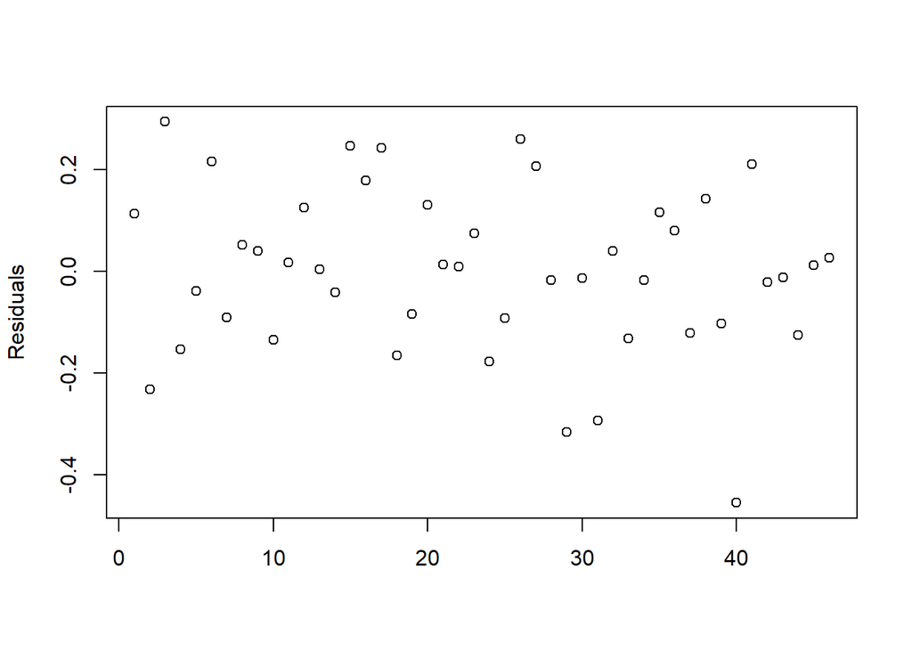

```r
plot(reg$residuals, ylab = "Residuals", xlab = "")
```

Al graficar los residuales, no parece haber heteroscedasticidad, pero hay que hacer pruebas de hipótesis para tener mayor precisión.

## 4. A mano, has la prueba de Goldfeld y Quandt para 3 grupos e indica si hay heteroscedasticidad.

Primero se ordena la base de datos en base a el precio. Se obtienen dos submuestras de la base de datos, una con los precios más bajos, y la otra con los precios más altos. En este caso las submuestras tienen 15 observaciones.

```r
dfo <- df[order(df$price, decreasing = F),]
df1 <- dfo[1:15,]
df2 <- dfo[32:46,]
```

Se corre la regresión para cada submuestra, y se obtienen los residuales.

```r
reg1 <- lm(df1$packs ~ df1$price)
res1 <- matrix(reg1$residuals)
reg2 <- lm(df2$packs ~ df2$price)
res2 <- matrix(reg2$residuals)
```

Para obtener el estadístico de prueba, se divide la suma de cuadrados de los residuales entre los grados de libertad; luego de estas divisiones se dividen entre ellas, usando la de la submuestra con los valores más altos de precio como numerador.

```r
(t(res2)%*%res2/13)/(t(res1)%*%res1/13)
```

```
##          [,1]
## [1,] 1.021669
```

Posteriormente se obtiene el estadístico F, con un nivel de significancia del 0.05.

```r
qf(p = 0.05, df1 = 13, df2 = 13, lower.tail = F)
```

```
## [1] 2.576927
```

El estadístico de prueba se encuentra fuera de la zona de rechazo, por lo que decimos que no hay heteroscedasticidad.

## 5. Corre una regresión de MCO incluyendo la variable income a la regresion anterior.

```r
reg3 <- lm(df$packs ~ df$price + df$income)
summary(reg3)
```

```
##
## Call:
## lm(formula = df$packs ~ df$price + df$income)
##
## Residuals:
##      Min       1Q   Median       3Q      Max
## -0.41867 -0.10683  0.00757  0.11738  0.32868
##
## Coefficients:
##             Estimate Std. Error t value Pr(>|t|)
## (Intercept)   4.2997     0.9089   4.730 2.43e-05 ***
## df$price     -1.3383     0.3246  -4.123 0.000168 ***
## df$income     0.1724     0.1968   0.876 0.385818
## ---
## Signif. codes:  0 '***' 0.001 '**' 0.01 '*' 0.05 '.' 0.1 ' ' 1
##
## Residual standard error: 0.1634 on 43 degrees of freedom
## Multiple R-squared:  0.3037, Adjusted R-squared:  0.2713
## F-statistic: 9.378 on 2 and 43 DF,  p-value: 0.0004168
```

De nuevo los coeficientes tienen sentido, entre mayor el precio del paquete, menor será la cantidad que se venda; y entre mayor sea el ingreso, más cantidad de éstas se venderá. Sin embargo, se encuentra que la variable ingreso no es estadísticamente significativa.

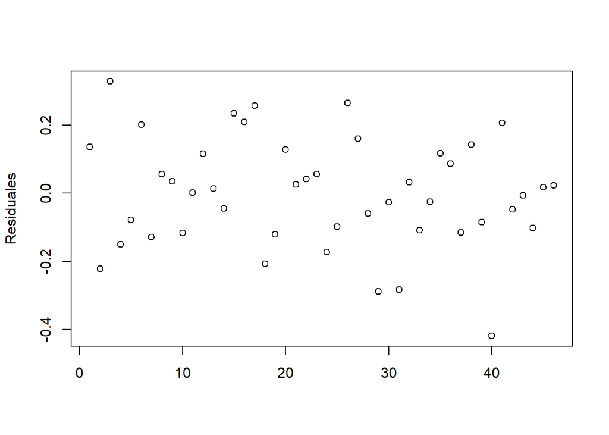

```r
plot(reg3$residuals, ylab = "Residuales", xlab = "")
```

Al graficar los residuales, no parece que haya heteroscedasticidad.

## 6. Utilizando la funcion de R y eliminando 12 observaciones del centro, realiza la prueba de Golgfeld y Quandt

```r
gqtest(reg3, order.by = df$price, fraction = 12)
```

```
##
##  Goldfeld-Quandt test
##
## data:  reg3
## GQ = 0.78076, df1 = 14, df2 = 14, p-value = 0.6752
## alternative hypothesis: variance increases from segment 1 to 2
```

```r
gqtest(reg3, order.by = df$income, fraction = 12)
```

```
##
##  Goldfeld-Quandt test
##
## data:  reg3
## GQ = 0.31846, df1 = 14, df2 = 14, p-value = 0.9798
## alternative hypothesis: variance increases from segment 1 to 2
```

Ordenando por precios, el p-value obtenido es de 0.6752, con un nivel de significancia del 0.05, no rechazamos la hipótesis nula, ésta prueba indica que hay homoscedasticidad. Ordenando por ingreso, el p-value obtenido es 0.9798, también indica que hay homoscedasticidad.

## 7.Investiga como se hace la prueba de Breusch-Pagan teoricamente y realiza la prueba de Breusch-Pagan con ayuda de R. Indica si hay heteroscedasticidad.

## Breusch-Pagan

La prueba Breush-Pagan sirve para saber si existe heterocedasticidad

Los pasos al realizar esta prueba son los siguientes:

1. Corrrer MCO para toda la muestra.
2. Obtener los estimadores $\hat{B}$ y $\hat{u}$.
3. Correr la regrsión auxiliar de mi estimador de $u$ contra cualquier combinación de $X$
4. Obtenemos el estadístico de prueba:

$\lambda = \frac{S_0}{2\sigma^2} > X_r^2$ , donde:

$S_0$ es la suma de los cuadrados de los residuales de la regresión auxiliar, y

$\sigma^2 = \frac{\sum\hat{u}^2}{n}$

```r
bptest(reg3, studentize = F)
```

```
##
##  Breusch-Pagan test
##
## data:  reg3
## BP = 6.1816, df = 2, p-value = 0.04547
```

Se obtiene un p-value de 0.04547. con un nivel de significancia del 0.05, rechazamos la hipótesis nula, decimos que sí hay heteroscedasticidad.

## 8. Realiza la prueba de White e indica si hay heteroscedasticidad.

```r
bptest(reg3, ~ df$price^2 + df$income^2 + df$price*df$income)
```

```
##
##  studentized Breusch-Pagan test
##
## data:  reg3
## BP = 6.9284, df = 3, p-value = 0.07422
```

Obtenemos un p-value de 0.07422, con un nivel de significancia del 0.05 no se rechaza la hipótesis nula, por lo que esta prueba indica que hay homoscedasticidad.

## 9. En caso de ser necesario corrige las regresiones utilizando el estimador de White de la varianza asintótica de beta.

```r
#Corregida por White:
vcovHC(reg3)
```

```
##             (Intercept)    df$price   df$income
## (Intercept)   1.3486844  0.26842214 -0.29138366
## df$price      0.2684221  0.14398409 -0.06218249
## df$income    -0.2913837 -0.06218249  0.06316924
```

```r
#Original:
vcov(reg3)
```

```
##             (Intercept)    df$price   df$income
## (Intercept)   0.8261459  0.12850402 -0.17840687
## df$price      0.1285040  0.10536611 -0.03144364
## df$income    -0.1784069 -0.03144364  0.03871229
```

Dos pruebas de hipótesis nos señalaban homoscedasticidad, mientras que una señalaba heteroscedasticidad, por ello es importante corregir para saber si la heteroscedasticidad es un problema o no.

## 10. Corre los siguientes comandos y explica que es lo que hacen estos comandos.

El comando gqtest() nos sirve para realizar la prueba Goldfeld-Quandt, en los paréntesis se indica la regresión sobre la que se hace la prueba, y se pone fraction = para indicar cuántos datos de en medio serán los omitidos.

El comando bptest() sirve para realizar la prueba Breusch-Pagan. En los paréntesis se indica la regresión sobre la que se hace la prueba.

El comando bptest(,~) sirve para hacer la prueba de White, primero se pone la regresión sobre la que se hace la prueba, después se pone una coma y una ~, con la que después se indican las variables extra con las que se hará la regresión auxiliar.

El comando vcovHC() nos ayuda a obtener la matriz varianza-covarianza de la regresión corregida por White. En el paréntesis se indica la regresión que se corrige.